# Monthly model - Regions

Tanya Rogers

1/6/2022

```r
library(dplyr)
#library(psych) #for pairs.panels, but could use other packages, e.g. GGalley
library(lavaan)
library(semPlot)
library(DiagrammeR)
library(ggplot2)
library(tidyr)
```

### Import data

```r
combined=read.csv("data/monthly_averages/monthly_data_compiled_regions.csv",stringsAsFactors = F)
cnames=read.csv("analysis/column_names_region_monthly.csv", stringsAsFactors = F)
dsub=filter(combined, Year>=1995) %>% arrange(Region,Year,Month)
focaldata=dsub[,cnames$Datacolumn]
fvars=cnames$Shortname
colnames(focaldata)=fvars
regions=unique(focaldata$region)
regionorder=c("Far West","West","North","South")
focaldata=focaldata%>%
  mutate(decyear=year+(month-1)/12,
         sinmon=sin(2*pi/12*month),
         cosmon=cos(2*pi/12*month))

#focal variables
varnames=c("temp", "flow","nitrate","ammonia","dophos","chla","hcope","clad","amphi","pcope","mysid","potam","corbic","sside","estfish_bsot","estfish_bsmt")

source("analysis/myLavaanPlot.r")
```

Notes:  
Determine which vars are appropriate for which regions and at what lags.  
Write out path diagram for each region.  
Model with and without fish, probably, because of missing data.

### Data prep

Log transform, scale.  
Within and across regions.  
Create set with regional monthly means removed.

```r
#log transform
logvars=fvars[cnames$Log=="yes"]
logtrans=function(x) {
  x2=x[which(!is.na(x))]
  if(any(x2==0)) {log(x+min(x2[which(x2>0)],na.rm=T))}
  else {log(x)}
}
focaldatalog = focaldata %>%
  mutate_at(logvars,logtrans)

#scale data
fdr0=focaldatalog
tvars=fvars[-(1:3)]

#scaled within regions
fdr=fdr0 %>%
  group_by(region) %>%
  #scale
  mutate_at(tvars,scale) %>%
  #lag
  mutate_at(tvars,list("1"=lag,"2"=function(x) {lag(x,2)})) %>%
  ungroup() %>%
  as.data.frame()

#scaled within regions, remove monthly means
fdr_ds=fdr %>%
  group_by(region,month) %>%
  mutate_at(tvars,list("mm"=function(x) {mean(x,na.rm = T)})) %>%
  mutate_at(tvars,function(x) {x-mean(x,na.rm = T)}) %>%
  ungroup() %>%
  #lag
  group_by(region) %>%
  mutate_at(tvars,list("1"=lag,"2"=function(x) {lag(x,2)})) %>%
  ungroup() %>%
  as.data.frame()

#scaled across regions
fdr1=fdr0 %>%
  #scale
  mutate_at(tvars,scale) %>%
  #lag
  group_by(region) %>%
  mutate_at(tvars,list("1"=lag,"2"=function(x) {lag(x,2)})) %>%
  ungroup() %>%
  as.data.frame()

#scaled across regions, monthly means removed
fdr1_ds=fdr1 %>%
  group_by(region,month) %>%
  mutate_at(tvars,list("mm"=function(x) {mean(x,na.rm = T)})) %>%
  mutate_at(tvars,function(x) {x-mean(x,na.rm = T)}) %>%
  ungroup() %>%
  #lag
  group_by(region) %>%
  mutate_at(tvars,list("1"=lag,"2"=function(x) {lag(x,2)})) %>%
  ungroup() %>%
  as.data.frame()
```

Data availability by series and region (prop zeros and prop missing)

FW: ignore clad, corbic, sside  
W: ignore corbic, sside  
S: ignore potam

```r
dataavail=focaldata %>%
  gather(var, value, 4:length(fvars)) %>%
  group_by(region, var) %>%
  summarize(
    propmissing=length(which(is.na(value)))/length(value),
    propzeros=length(which(value==0))/length(which(!is.na(value)))) %>%
  as.data.frame()

#these variables should not be used (too many zeros)
filter(dataavail,propzeros>0.5 | is.na(propzeros))
```

```
##      region          var propmissing propzeros
## 1  Far West         clad   0.1382637 0.9514925
## 2  Far West       corbic   0.1382637 1.0000000
## 3  Far West marfish_bsot   0.4565916 0.6508876
## 4  Far West   sbass_bsmt   0.4951768 0.7515924
## 5  Far West   sbass_bsot   0.4565916 0.6982249
## 6  Far West   smelt_bsmt   0.4951768 0.9808917
## 7  Far West   smelt_bsot   0.4565916 0.9940828
## 8  Far West        sside   1.0000000       NaN
## 9     North    lfin_bsmt   0.5144695 0.8741722
## 10    North    lfin_bsot   0.4694534 0.9393939
## 11    North marfish_bsmt   0.5144695 0.9735099
## 12    North marfish_bsot   0.4694534 0.9939394
## 13    North   smelt_bsot   0.4694534 0.8242424
## 14    South    lfin_bsmt   0.5128205 1.0000000
## 15    South    lfin_bsot   0.4679487 1.0000000
## 16    South marfish_bsmt   0.5128205 1.0000000
## 17    South marfish_bsot   0.4679487 1.0000000
## 18    South        potam   0.1378205 0.9702602
## 19    South   sbass_bsmt   0.5128205 0.6118421
## 20    South   smelt_bsmt   0.5128205 0.8486842
## 21    South   smelt_bsot   0.4679487 0.9156627
## 22     West       corbic   0.1350482 0.8066914
## 23     West marfish_bsot   0.4598071 0.9047619
## 24     West   smelt_bsmt   0.4983923 0.5128205
## 25     West   smelt_bsot   0.4598071 0.7619048
## 26     West        sside   1.0000000       NaN
```

```r
#these variables have lots of missing data
filter(dataavail,propmissing>0.45 | is.na(propmissing))
```

```
##      region          var propmissing   propzeros
## 1  Far West estfish_bsmt   0.4951768 0.165605096
## 2  Far West estfish_bsot   0.4565916 0.201183432
## 3  Far West    lfin_bsmt   0.4951768 0.356687898
## 4  Far West    lfin_bsot   0.4565916 0.248520710
## 5  Far West marfish_bsmt   0.4951768 0.006369427
## 6  Far West marfish_bsot   0.4565916 0.650887574
## 7  Far West   sbass_bsmt   0.4951768 0.751592357
## 8  Far West   sbass_bsot   0.4565916 0.698224852
## 9  Far West   smelt_bsmt   0.4951768 0.980891720
## 10 Far West   smelt_bsot   0.4565916 0.994082840
## 11 Far West        sside   1.0000000         NaN
## 12    North estfish_bsmt   0.5176849 0.126666667
## 13    North estfish_bsot   0.4694534 0.109090909
## 14    North    lfin_bsmt   0.5144695 0.874172185
```

[output cut: 28 more lines]

### Time series plots

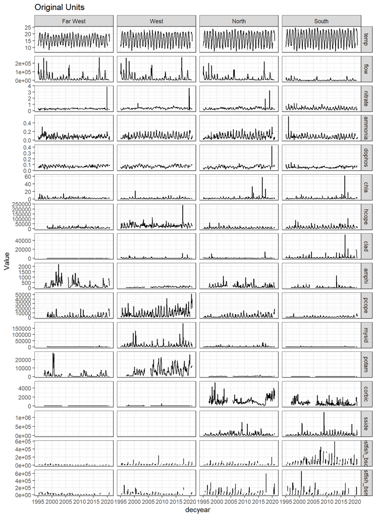

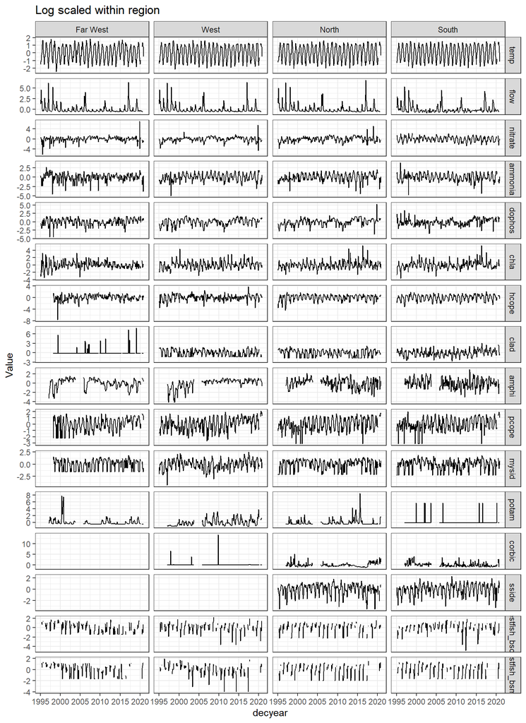

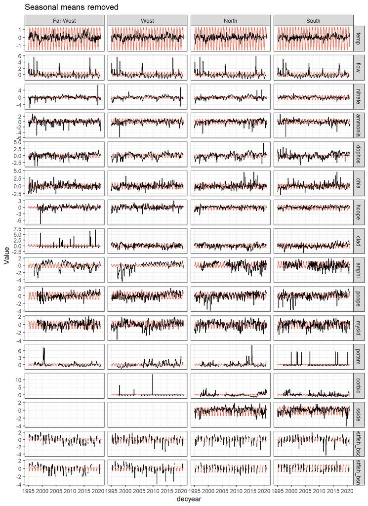

### Cross-correlation matrices

(only sig correlations shown… no correction for multiple comparisons)

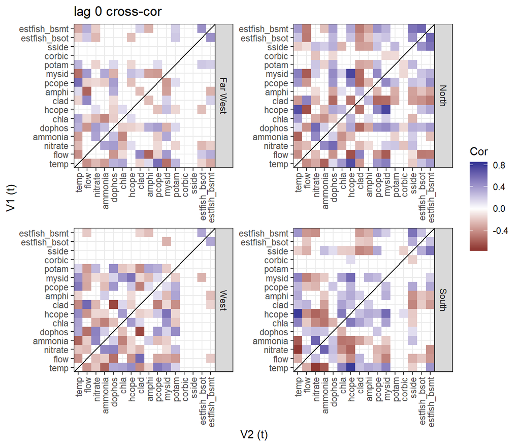

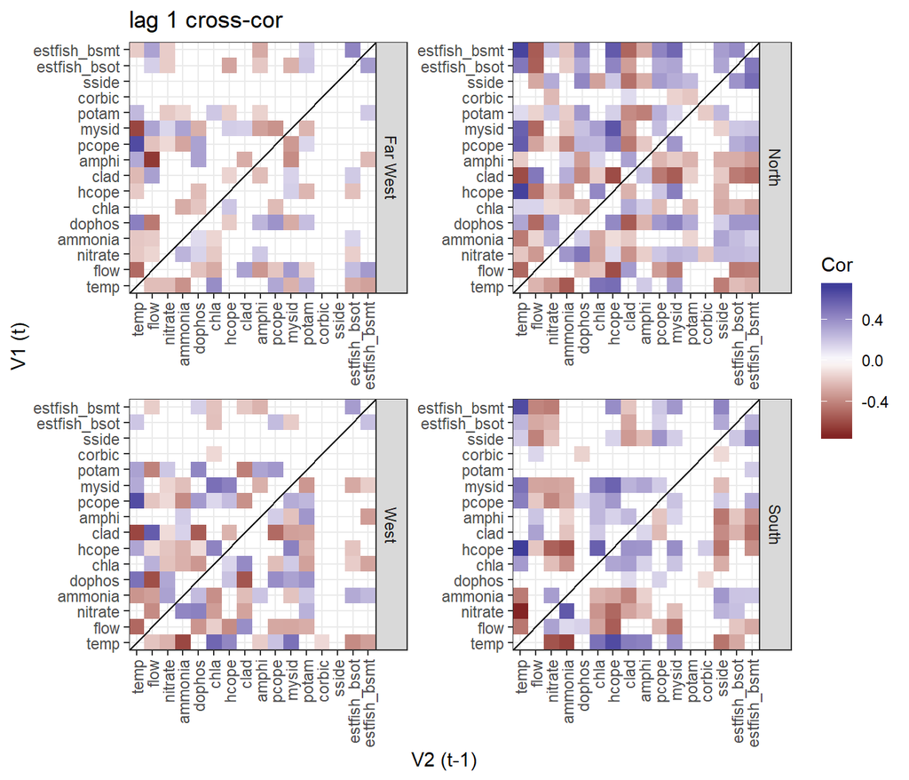

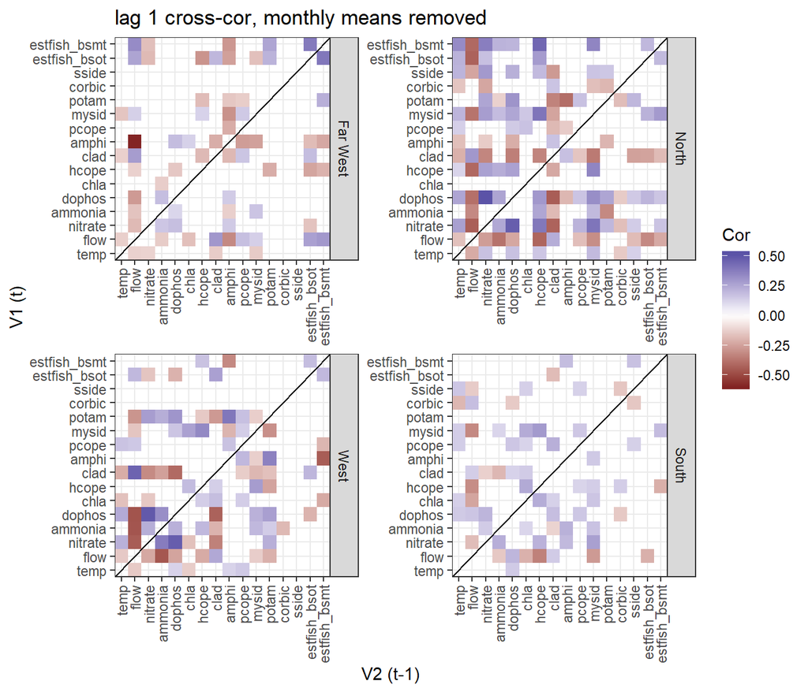

Other notes:

*Detrended fish indices are NOT correlated in S!*

Nitrate and ammonia are positively correlated, max at lag 0 all regions.  
Nitrate and dophos are positively correlated, max at lag 0 all regions.  
Ammonia and dophos are positively correlated, lag 0 for FW and S, ammonia lags dphos by 3 months in W and N.

Chla nitrate neg correlated, lag 0.  
Chla ammonia neg correlated, lag 0.  
Chla dophos relationship unclear.

High flow 2-4 month prev = high chla

Mysid and hcope postive, lag 0.  
In S and W, hcope lags pcope, negative.

### SEM model

I haven’t looked in to how to modify the new (nicer) plotting code to work with the lags and multiple groups, but that is something that can be done.

I haven’t added corbic and sside, but that is something to explore.

#### Chla, nutrients, flow

May want to add clams here.

```r
mod1='chla~ammonia+dophos+chla_1
      ammonia~flow_1+chla_1
      dophos~flow_1+chla_1
      ammonia~~dophos'

#you can either do a multigroup model by region
modfit1=sem(mod1, data=fdr_ds, group = "region")
summary(modfit1, standardized=T, rsq=T)
```

```
## lavaan 0.6-4 ended normally after 28 iterations
##
##   Optimization method                           NLMINB
##   Number of free parameters                         56
##
##                                                   Used       Total
##   Number of observations per group
##   Far West                                         297         311
##   North                                            304         311
##   South                                            303         312
##   West                                             304         311
##
##   Estimator                                         ML
##   Model Fit Test Statistic                      14.528
##   Degrees of freedom                                 4
##   P-value (Chi-square)                           0.006
##
## Chi-square for each group:
##
##   Far West                                       3.688
##   North                                          1.020
##   South                                          9.808
##   West                                           0.012
##
## Parameter Estimates:
##
##   Information                                 Expected
##   Information saturated (h1) model          Structured
##   Standard Errors                             Standard
##
##
## Group 1 [Far West]:
##
## Regressions:
##                    Estimate  Std.Err  z-value  P(>|z|)   Std.lv  Std.all
##   chla ~
##     ammonia          -0.270    0.054   -5.050    0.000   -0.270   -0.283
##     dophos           -0.055    0.060   -0.915    0.360   -0.055   -0.051
##     chla_1            0.323    0.052    6.221    0.000    0.323    0.325
##   ammonia ~
```

[output cut: 130 more lines]

```
##    .chla              0.008    0.037    0.206    0.836    0.008    0.011
##    .ammonia           0.008    0.037    0.216    0.829    0.008    0.011
##    .dophos           -0.007    0.042   -0.175    0.861   -0.007   -0.009
##
## Variances:
##                    Estimate  Std.Err  z-value  P(>|z|)   Std.lv  Std.all
##    .chla              0.422    0.034   12.329    0.000    0.422    0.853
##    .ammonia           0.427    0.035   12.329    0.000    0.427    0.770
##    .dophos            0.535    0.043   12.329    0.000    0.535    0.753
##
## R-Square:
##                    Estimate
##     chla              0.147
##     ammonia           0.230
##     dophos            0.247
```

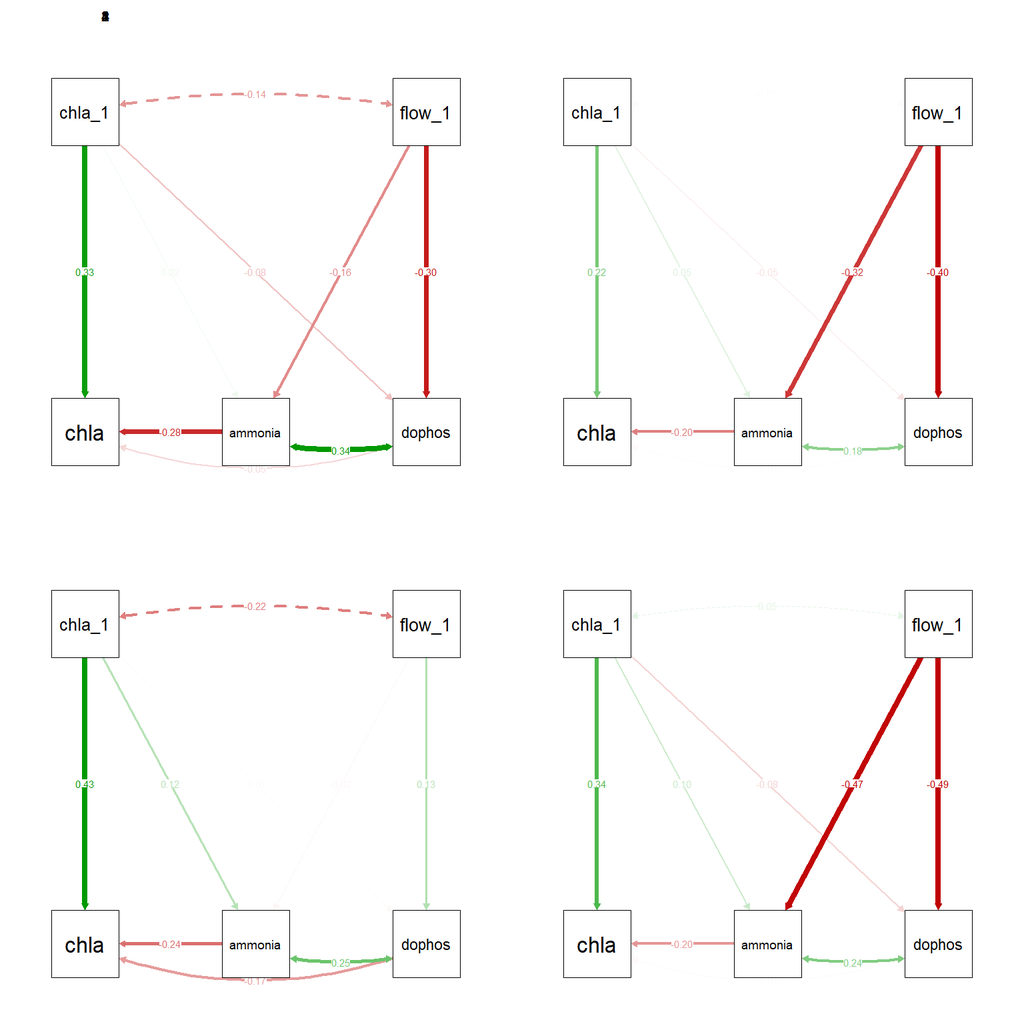

```r
par(mfrow=c(2,2))
semPaths(modfit1, "std", edge.label.cex = 1, residuals = F,  node.width=3, nCharNodes = 0, intercepts = F, title = T)
```

```r
#residuals(modfit1)

#or fit separately for each region
modfitFW=sem(mod1, data=filter(fdr_ds,region=="Far West"))
modfitW=sem(mod1, data=filter(fdr_ds,region=="West"))
modfitN=sem(mod1, data=filter(fdr_ds,region=="North"))
modfitS=sem(mod1, data=filter(fdr_ds,region=="South"))
summary(modfitFW, standardized=T, rsq=T)
```

```
## lavaan 0.6-4 ended normally after 18 iterations
##
##   Optimization method                           NLMINB
##   Number of free parameters                         11
##
##                                                   Used       Total
##   Number of observations                           297         311
##
##   Estimator                                         ML
##   Model Fit Test Statistic                       3.688
##   Degrees of freedom                                 1
##   P-value (Chi-square)                           0.055
##
## Parameter Estimates:
##
##   Information                                 Expected
##   Information saturated (h1) model          Structured
##   Standard Errors                             Standard
##
## Regressions:
##                    Estimate  Std.Err  z-value  P(>|z|)   Std.lv  Std.all
##   chla ~
##     ammonia          -0.270    0.054   -5.050    0.000   -0.270   -0.283
##     dophos           -0.055    0.060   -0.915    0.360   -0.055   -0.051
##     chla_1            0.323    0.052    6.221    0.000    0.323    0.325
##   ammonia ~
##     flow_1           -0.165    0.061   -2.690    0.007   -0.165   -0.156
##     chla_1            0.022    0.060    0.363    0.717    0.022    0.021
##   dophos ~
##     flow_1           -0.287    0.053   -5.461    0.000   -0.287   -0.305
##     chla_1           -0.076    0.052   -1.469    0.142   -0.076   -0.082
##
## Covariances:
##                    Estimate  Std.Err  z-value  P(>|z|)   Std.lv  Std.all
##  .ammonia ~~
##    .dophos            0.221    0.040    5.535    0.000    0.221    0.339
##
## Variances:
##                    Estimate  Std.Err  z-value  P(>|z|)   Std.lv  Std.all
##    .chla              0.575    0.047   12.186    0.000    0.575    0.807
##    .ammonia           0.762    0.063   12.186    0.000    0.762    0.974
##    .dophos            0.558    0.046   12.186    0.000    0.558    0.907
##
## R-Square:
##                    Estimate
##     chla              0.193
##     ammonia           0.026
##     dophos            0.093
```

```r
summary(modfitW, standardized=T, rsq=T)
```

```
## lavaan 0.6-4 ended normally after 19 iterations
##
##   Optimization method                           NLMINB
##   Number of free parameters                         11
##
##                                                   Used       Total
##   Number of observations                           304         311
##
##   Estimator                                         ML
##   Model Fit Test Statistic                       0.012
##   Degrees of freedom                                 1
##   P-value (Chi-square)                           0.914
##
## Parameter Estimates:
##
##   Information                                 Expected
##   Information saturated (h1) model          Structured
##   Standard Errors                             Standard
##
## Regressions:
##                    Estimate  Std.Err  z-value  P(>|z|)   Std.lv  Std.all
##   chla ~
##     ammonia          -0.189    0.055   -3.424    0.001   -0.189   -0.200
##     dophos           -0.009    0.049   -0.185    0.853   -0.009   -0.011
##     chla_1            0.338    0.054    6.310    0.000    0.338    0.339
##   ammonia ~
##     flow_1           -0.426    0.045   -9.407    0.000   -0.426   -0.474
##     chla_1            0.110    0.053    2.064    0.039    0.110    0.104
##   dophos ~
##     flow_1           -0.494    0.051   -9.749    0.000   -0.494   -0.486
##     chla_1           -0.097    0.059   -1.628    0.104   -0.097   -0.081
##
## Covariances:
##                    Estimate  Std.Err  z-value  P(>|z|)   Std.lv  Std.all
##  .ammonia ~~
##    .dophos            0.116    0.028    4.106    0.000    0.116    0.242
##
## Variances:
##                    Estimate  Std.Err  z-value  P(>|z|)   Std.lv  Std.all
##    .chla              0.422    0.034   12.329    0.000    0.422    0.853
##    .ammonia           0.427    0.035   12.329    0.000    0.427    0.770
##    .dophos            0.535    0.043   12.329    0.000    0.535    0.753
##
## R-Square:
##                    Estimate
##     chla              0.147
##     ammonia           0.230
##     dophos            0.247
```

```r
summary(modfitN, standardized=T, rsq=T)
```

```
## lavaan 0.6-4 ended normally after 15 iterations
##
##   Optimization method                           NLMINB
##   Number of free parameters                         11
##
##                                                   Used       Total
##   Number of observations                           304         311
##
##   Estimator                                         ML
##   Model Fit Test Statistic                       1.020
##   Degrees of freedom                                 1
##   P-value (Chi-square)                           0.312
##
## Parameter Estimates:
##
##   Information                                 Expected
##   Information saturated (h1) model          Structured
##   Standard Errors                             Standard
##
## Regressions:
##                    Estimate  Std.Err  z-value  P(>|z|)   Std.lv  Std.all
##   chla ~
##     ammonia          -0.215    0.060   -3.554    0.000   -0.215   -0.204
##     dophos           -0.007    0.051   -0.136    0.892   -0.007   -0.008
##     chla_1            0.216    0.055    3.929    0.000    0.216    0.216
##   ammonia ~
##     flow_1           -0.293    0.050   -5.840    0.000   -0.293   -0.317
##     chla_1            0.047    0.051    0.915    0.360    0.047    0.050
##   dophos ~
##     flow_1           -0.442    0.057   -7.730    0.000   -0.442   -0.405
##     chla_1           -0.052    0.059   -0.878    0.380   -0.052   -0.046
##
## Covariances:
##                    Estimate  Std.Err  z-value  P(>|z|)   Std.lv  Std.all
##  .ammonia ~~
##    .dophos            0.108    0.035    3.104    0.002    0.108    0.181
##
## Variances:
##                    Estimate  Std.Err  z-value  P(>|z|)   Std.lv  Std.all
##    .chla              0.595    0.048   12.329    0.000    0.595    0.915
##    .ammonia           0.524    0.043   12.329    0.000    0.524    0.897
##    .dophos            0.682    0.055   12.329    0.000    0.682    0.834
##
## R-Square:
##                    Estimate
##     chla              0.085
##     ammonia           0.103
##     dophos            0.166
```

```r
summary(modfitS, standardized=T, rsq=T)
```

```
## lavaan 0.6-4 ended normally after 16 iterations
##
##   Optimization method                           NLMINB
##   Number of free parameters                         11
##
##                                                   Used       Total
##   Number of observations                           303         312
##
##   Estimator                                         ML
##   Model Fit Test Statistic                       9.808
##   Degrees of freedom                                 1
##   P-value (Chi-square)                           0.002
##
## Parameter Estimates:
##
##   Information                                 Expected
##   Information saturated (h1) model          Structured
##   Standard Errors                             Standard
##
## Regressions:
##                    Estimate  Std.Err  z-value  P(>|z|)   Std.lv  Std.all
##   chla ~
##     ammonia          -0.267    0.057   -4.675    0.000   -0.267   -0.239
##     dophos           -0.141    0.043   -3.249    0.001   -0.141   -0.165
##     chla_1            0.424    0.050    8.541    0.000    0.424    0.425
##   ammonia ~
##     flow_1           -0.013    0.051   -0.258    0.797   -0.013   -0.015
##     chla_1            0.108    0.052    2.071    0.038    0.108    0.121
##   dophos ~
##     flow_1            0.144    0.066    2.191    0.028    0.144    0.128
##     chla_1           -0.012    0.068   -0.171    0.864   -0.012   -0.010
##
## Covariances:
##                    Estimate  Std.Err  z-value  P(>|z|)   Std.lv  Std.all
##  .ammonia ~~
##    .dophos            0.168    0.040    4.155    0.000    0.168    0.246
##
## Variances:
##                    Estimate  Std.Err  z-value  P(>|z|)   Std.lv  Std.all
##    .chla              0.486    0.040   12.309    0.000    0.486    0.736
##    .ammonia           0.523    0.042   12.309    0.000    0.523    0.984
##    .dophos            0.890    0.072   12.309    0.000    0.890    0.983
##
## R-Square:
##                    Estimate
##     chla              0.264
##     ammonia           0.016
##     dophos            0.017
```

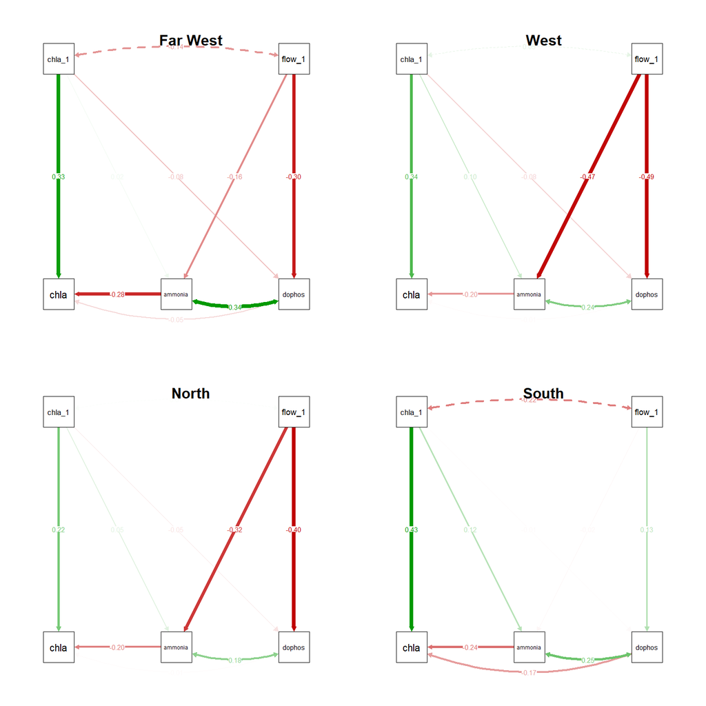

```r
par(mfrow=c(2,2))
semPaths(modfitFW, "std", edge.label.cex = 1, node.width=2, nCharNodes = 0, residuals = F, intercepts = F); title("Far West", line = 1)
semPaths(modfitW, "std", edge.label.cex = 1, node.width=2, nCharNodes = 0, residuals = F, intercepts = F); title("West", line = 1)
semPaths(modfitN, "std", edge.label.cex = 1, node.width=2, nCharNodes = 0, residuals = F, intercepts = F); title("North", line = 1)
semPaths(modfitS, "std", edge.label.cex = 1, node.width=2, nCharNodes = 0, residuals = F, intercepts = F); title("South", line = 1)
```

```r
#residuals(modfitFW)
```

#### Chla, zooplankton

This definitely needs work.

```r
modFW='chla~chla_1+hcope_1+potam_1+amphi_1
       hcope~chla_1+hcope_1
       potam~chla_1+potam_1
       amphi~chla_1+amphi_1
'
modWN='chla~chla_1+hcope_1+potam_1+amphi_1+clad_1
       hcope~chla_1+hcope_1
       potam~chla_1+potam_1
       amphi~chla_1+amphi_1
       clad~chla_1+clad_1
'
modS='chla~chla_1+hcope_1+amphi_1+clad_1
       hcope~chla_1+hcope_1
       amphi~chla_1+amphi_1
       clad~chla_1+clad_1
'
modfitFW=sem(modFW, data=filter(fdr_ds,region=="Far West"))
modfitW=sem(modWN, data=filter(fdr_ds,region=="West"))
modfitN=sem(modWN, data=filter(fdr_ds,region=="North"))
modfitS=sem(modS, data=filter(fdr_ds,region=="South"))
summary(modfitFW, standardized=T, rsq=T)
```

```
## lavaan 0.6-4 ended normally after 25 iterations
##
##   Optimization method                           NLMINB
##   Number of free parameters                         20
##
##                                                   Used       Total
##   Number of observations                           234         311
##
##   Estimator                                         ML
##   Model Fit Test Statistic                      18.231
##   Degrees of freedom                                 6
##   P-value (Chi-square)                           0.006
##
## Parameter Estimates:
##
##   Information                                 Expected
##   Information saturated (h1) model          Structured
##   Standard Errors                             Standard
##
## Regressions:
##                    Estimate  Std.Err  z-value  P(>|z|)   Std.lv  Std.all
##   chla ~
##     chla_1            0.237    0.063    3.753    0.000    0.237    0.239
##     hcope_1           0.056    0.054    1.037    0.300    0.056    0.067
##     potam_1          -0.014    0.045   -0.303    0.762   -0.014   -0.019
##     amphi_1           0.076    0.048    1.595    0.111    0.076    0.101
##   hcope ~
##     chla_1            0.053    0.082    0.645    0.519    0.053    0.039
##     hcope_1           0.467    0.069    6.759    0.000    0.467    0.405
##   potam ~
##     chla_1            0.073    0.069    1.056    0.291    0.073    0.051
##     potam_1           0.672    0.049   13.846    0.000    0.672    0.668
##   amphi ~
##     chla_1            0.042    0.044    0.960    0.337    0.042    0.032
##     amphi_1           0.846    0.033   25.440    0.000    0.846    0.855
##
## Covariances:
##                    Estimate  Std.Err  z-value  P(>|z|)   Std.lv  Std.all
##  .chla ~~
##    .hcope             0.028    0.037    0.741    0.458    0.028    0.049
##    .potam             0.031    0.032    0.999    0.318    0.031    0.065
##    .amphi            -0.003    0.020   -0.170    0.865   -0.003   -0.011
##  .hcope ~~
##    .potam             0.050    0.041    1.219    0.223    0.050    0.080
##    .amphi             0.012    0.026    0.471    0.637    0.012    0.031
##  .potam ~~
##    .amphi             0.017    0.022    0.766    0.444    0.017    0.050
##
## Variances:
##                    Estimate  Std.Err  z-value  P(>|z|)   Std.lv  Std.all
##    .chla              0.434    0.040   10.817    0.000    0.434    0.916
##    .hcope             0.747    0.069   10.817    0.000    0.747    0.830
##    .potam             0.533    0.049   10.817    0.000    0.533    0.550
##    .amphi             0.215    0.020   10.817    0.000    0.215    0.262
##
## R-Square:
##                    Estimate
##     chla              0.084
##     hcope             0.170
##     potam             0.450
##     amphi             0.738
```

```r
summary(modfitW, standardized=T, rsq=T)
```

```
## lavaan 0.6-4 ended normally after 33 iterations
##
##   Optimization method                           NLMINB
##   Number of free parameters                         28
##
##                                                   Used       Total
##   Number of observations                           257         311
##
##   Estimator                                         ML
##   Model Fit Test Statistic                      29.989
##   Degrees of freedom                                12
##   P-value (Chi-square)                           0.003
##
## Parameter Estimates:
##
##   Information                                 Expected
##   Information saturated (h1) model          Structured
##   Standard Errors                             Standard
##
## Regressions:
##                    Estimate  Std.Err  z-value  P(>|z|)   Std.lv  Std.all
##   chla ~
##     chla_1            0.183    0.060    3.036    0.002    0.183    0.185
##     hcope_1           0.072    0.050    1.420    0.156    0.072    0.088
##     potam_1          -0.004    0.050   -0.071    0.943   -0.004   -0.005
##     amphi_1           0.055    0.044    1.249    0.212    0.055    0.079
##     clad_1            0.220    0.054    4.048    0.000    0.220    0.246
##   hcope ~
##     chla_1            0.067    0.072    0.932    0.351    0.067    0.056
##     hcope_1           0.350    0.058    5.998    0.000    0.350    0.353
##   potam ~
##     chla_1           -0.027    0.052   -0.520    0.603   -0.027   -0.020
##     potam_1           0.772    0.038   20.105    0.000    0.772    0.775
##   amphi ~
##     chla_1            0.000    0.046    0.007    0.995    0.000    0.000
##     amphi_1           0.850    0.032   26.321    0.000    0.850    0.853
##   clad ~
##     chla_1            0.046    0.062    0.731    0.464    0.046    0.041
##     clad_1            0.444    0.055    8.090    0.000    0.444    0.444
##
```

[output cut: 17 more lines]

```
## Variances:
##                    Estimate  Std.Err  z-value  P(>|z|)   Std.lv  Std.all
##    .chla              0.406    0.036   11.336    0.000    0.406    0.874
##    .hcope             0.596    0.053   11.336    0.000    0.596    0.863
##    .potam             0.332    0.029   11.336    0.000    0.332    0.397
##    .amphi             0.260    0.023   11.336    0.000    0.260    0.272
##    .clad              0.465    0.041   11.336    0.000    0.465    0.797
##
## R-Square:
##                    Estimate
##     chla              0.126
##     hcope             0.137
##     potam             0.603
##     amphi             0.728
##     clad              0.203
```

```r
summary(modfitN, standardized=T, rsq=T)
```

```
## lavaan 0.6-4 ended normally after 31 iterations
##
##   Optimization method                           NLMINB
##   Number of free parameters                         28
##
##                                                   Used       Total
##   Number of observations                           255         311
##
##   Estimator                                         ML
##   Model Fit Test Statistic                      60.092
##   Degrees of freedom                                12
##   P-value (Chi-square)                           0.000
##
## Parameter Estimates:
##
##   Information                                 Expected
##   Information saturated (h1) model          Structured
##   Standard Errors                             Standard
##
## Regressions:
##                    Estimate  Std.Err  z-value  P(>|z|)   Std.lv  Std.all
##   chla ~
##     chla_1            0.153    0.061    2.488    0.013    0.153    0.154
##     hcope_1           0.016    0.092    0.176    0.860    0.016    0.011
##     potam_1          -0.072    0.068   -1.054    0.292   -0.072   -0.067
##     amphi_1           0.008    0.057    0.138    0.890    0.008    0.009
##     clad_1            0.130    0.072    1.811    0.070    0.130    0.121
##   hcope ~
##     chla_1           -0.013    0.038   -0.342    0.732   -0.013   -0.020
##     hcope_1           0.324    0.053    6.063    0.000    0.324    0.349
##   potam ~
##     chla_1           -0.048    0.048   -1.001    0.317   -0.048   -0.052
##     potam_1           0.542    0.050   10.900    0.000    0.542    0.554
##   amphi ~
##     chla_1            0.082    0.059    1.381    0.167    0.082    0.074
##     amphi_1           0.507    0.054    9.365    0.000    0.507    0.504
##   clad ~
##     chla_1           -0.061    0.051   -1.197    0.231   -0.061   -0.068
##     clad_1            0.432    0.053    8.087    0.000    0.432    0.441
##
```

[output cut: 17 more lines]

```
## Variances:
##                    Estimate  Std.Err  z-value  P(>|z|)   Std.lv  Std.all
##    .chla              0.645    0.057   11.292    0.000    0.645    0.949
##    .hcope             0.252    0.022   11.292    0.000    0.252    0.879
##    .potam             0.396    0.035   11.292    0.000    0.396    0.689
##    .amphi             0.612    0.054   11.292    0.000    0.612    0.742
##    .clad              0.452    0.040   11.292    0.000    0.452    0.807
##
## R-Square:
##                    Estimate
##     chla              0.051
##     hcope             0.121
##     potam             0.311
##     amphi             0.258
##     clad              0.193
```

```r
summary(modfitS, standardized=T, rsq=T)
```

```
## lavaan 0.6-4 ended normally after 28 iterations
##
##   Optimization method                           NLMINB
##   Number of free parameters                         20
##
##                                                   Used       Total
##   Number of observations                           257         312
##
##   Estimator                                         ML
##   Model Fit Test Statistic                       4.427
##   Degrees of freedom                                 6
##   P-value (Chi-square)                           0.619
##
## Parameter Estimates:
##
##   Information                                 Expected
##   Information saturated (h1) model          Structured
##   Standard Errors                             Standard
##
## Regressions:
##                    Estimate  Std.Err  z-value  P(>|z|)   Std.lv  Std.all
##   chla ~
##     chla_1            0.299    0.062    4.844    0.000    0.299    0.299
##     hcope_1           0.211    0.090    2.343    0.019    0.211    0.135
##     amphi_1          -0.067    0.055   -1.230    0.219   -0.067   -0.069
##     clad_1            0.055    0.061    0.894    0.371    0.055    0.054
##   hcope ~
##     chla_1            0.065    0.036    1.814    0.070    0.065    0.104
##     hcope_1           0.404    0.056    7.270    0.000    0.404    0.414
##   amphi ~
##     chla_1            0.064    0.063    1.026    0.305    0.064    0.062
##     amphi_1           0.214    0.060    3.538    0.000    0.214    0.213
##   clad ~
##     chla_1            0.067    0.053    1.264    0.206    0.067    0.069
##     clad_1            0.517    0.053    9.785    0.000    0.517    0.525
##
## Covariances:
##                    Estimate  Std.Err  z-value  P(>|z|)   Std.lv  Std.all
##  .chla ~~
##    .hcope             0.045    0.021    2.167    0.030    0.045    0.136
##    .amphi             0.013    0.037    0.363    0.717    0.013    0.023
##    .clad              0.119    0.031    3.867    0.000    0.119    0.249
##  .hcope ~~
##    .amphi            -0.003    0.022   -0.120    0.904   -0.003   -0.007
##    .clad              0.035    0.018    1.942    0.052    0.035    0.122
##  .amphi ~~
##    .clad             -0.067    0.033   -2.033    0.042   -0.067   -0.128
##
## Variances:
##                    Estimate  Std.Err  z-value  P(>|z|)   Std.lv  Std.all
##    .chla              0.545    0.048   11.336    0.000    0.545    0.855
##    .hcope             0.197    0.017   11.336    0.000    0.197    0.798
##    .amphi             0.644    0.057   11.336    0.000    0.644    0.950
##    .clad              0.422    0.037   11.336    0.000    0.422    0.700
##
## R-Square:
##                    Estimate
##     chla              0.145
##     hcope             0.202
##     amphi             0.050
##     clad              0.300
```

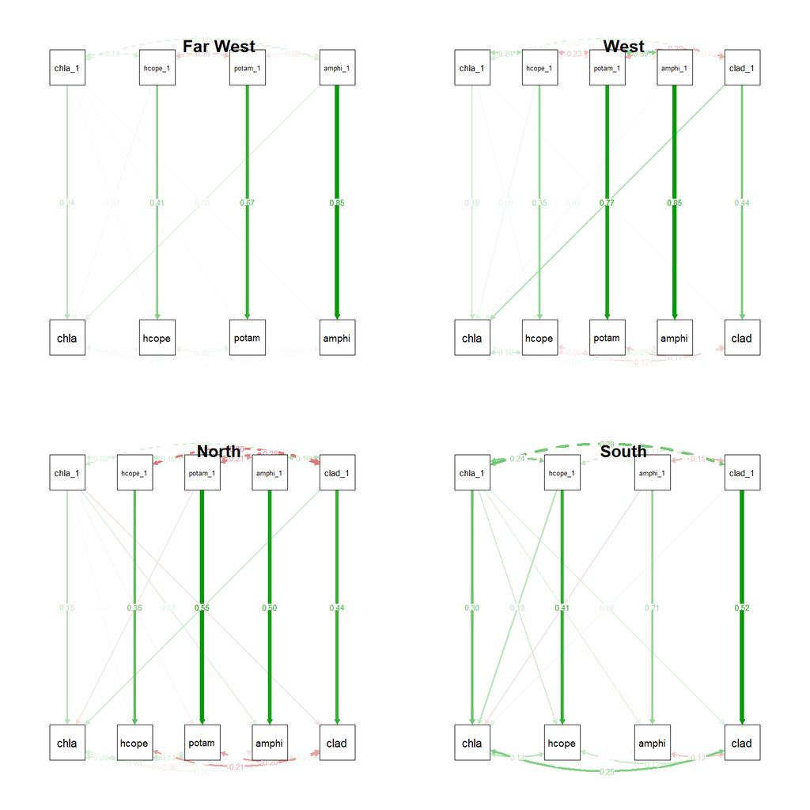

```r
#par(mfrow=c(1,1))
par(mfrow=c(2,2))
semPaths(modfitFW, "std", edge.label.cex = 1, node.width=2, nCharNodes = 0, residuals = F, intercepts = F); title("Far West", line = 1)
semPaths(modfitW, "std", edge.label.cex = 1, node.width=2, nCharNodes = 0, residuals = F, intercepts = F); title("West", line = 1)
semPaths(modfitN, "std", edge.label.cex = 1, node.width=2, nCharNodes = 0, residuals = F, intercepts = F); title("North", line = 1)
semPaths(modfitS, "std", edge.label.cex = 1, node.width=2, nCharNodes = 0, residuals = F, intercepts = F); title("South", line = 1)
```

#### Zooplankton, fish

Also needs work. Note that because fish have more missing data, more rows get dropped (compared ‘used’ and ‘total’ number of observations to previous summaries).

If you get a warning about variances being negative, that is **definitely** a problem. It seems to happen when you try to create a latent variables, but the variables that go into it don’t acutally have a common trend.

```r
modFW='fish=~estfish_bsmt+estfish_bsot
       fish~hcope_1+potam_1+amphi_1+flow_1
'
modWNS='fish=~estfish_bsmt+estfish_bsot
       fish~hcope_1+potam_1+amphi_1+clad_1+flow_1
'
modfitFW=sem(modFW, data=filter(fdr_ds,region=="Far West"))
modfitW=sem(modWNS, data=filter(fdr_ds,region=="West"))
modfitN=sem(modWNS, data=filter(fdr_ds,region=="North"))
modfitS=sem(modWNS, data=filter(fdr_ds,region=="South"))
summary(modfitFW, standardized=T, rsq=T)
```

```
## lavaan 0.6-4 ended normally after 21 iterations
##
##   Optimization method                           NLMINB
##   Number of free parameters                          8
##
##                                                   Used       Total
##   Number of observations                           125         311
##
##   Estimator                                         ML
##   Model Fit Test Statistic                       1.542
##   Degrees of freedom                                 3
##   P-value (Chi-square)                           0.673
##
## Parameter Estimates:
##
##   Information                                 Expected
##   Information saturated (h1) model          Structured
##   Standard Errors                             Standard
##
## Latent Variables:
##                    Estimate  Std.Err  z-value  P(>|z|)   Std.lv  Std.all
##   fish =~
##     estfish_bsmt      1.000                               0.562    0.616
##     estfish_bsot      0.936    0.233    4.024    0.000    0.526    0.548
##
## Regressions:
##                    Estimate  Std.Err  z-value  P(>|z|)   Std.lv  Std.all
##   fish ~
##     hcope_1          -0.190    0.059   -3.218    0.001   -0.339   -0.370
##     potam_1           0.146    0.057    2.571    0.010    0.260    0.289
##     amphi_1          -0.091    0.073   -1.251    0.211   -0.162   -0.170
##     flow_1            0.286    0.115    2.486    0.013    0.508    0.345
##
## Variances:
##                    Estimate  Std.Err  z-value  P(>|z|)   Std.lv  Std.all
##    .estfish_bsmt      0.516    0.101    5.086    0.000    0.516    0.620
##    .estfish_bsot      0.644    0.106    6.066    0.000    0.644    0.699
##    .fish              0.154    0.080    1.921    0.055    0.487    0.487
##
## R-Square:
##                    Estimate
##     estfish_bsmt      0.380
##     estfish_bsot      0.301
##     fish              0.513
```

```r
summary(modfitW, standardized=T, rsq=T)
```

```
## lavaan 0.6-4 ended normally after 23 iterations
##
##   Optimization method                           NLMINB
##   Number of free parameters                          9
##
##                                                   Used       Total
##   Number of observations                           132         311
##
##   Estimator                                         ML
##   Model Fit Test Statistic                      15.434
##   Degrees of freedom                                 4
##   P-value (Chi-square)                           0.004
##
## Parameter Estimates:
##
##   Information                                 Expected
##   Information saturated (h1) model          Structured
##   Standard Errors                             Standard
##
## Latent Variables:
##                    Estimate  Std.Err  z-value  P(>|z|)   Std.lv  Std.all
##   fish =~
##     estfish_bsmt      1.000                               0.501    0.541
##     estfish_bsot      0.382    0.204    1.872    0.061    0.192    0.234
##
## Regressions:
##                    Estimate  Std.Err  z-value  P(>|z|)   Std.lv  Std.all
##   fish ~
##     hcope_1           0.187    0.095    1.971    0.049    0.372    0.305
##     potam_1          -0.050    0.095   -0.532    0.595   -0.101   -0.088
##     amphi_1          -0.264    0.078   -3.376    0.001   -0.527   -0.524
##     clad_1            0.131    0.107    1.225    0.221    0.261    0.213
##     flow_1           -0.149    0.135   -1.104    0.270   -0.298   -0.198
##
## Variances:
##                    Estimate  Std.Err  z-value  P(>|z|)   Std.lv  Std.all
##    .estfish_bsmt      0.607    0.185    3.287    0.001    0.607    0.707
##    .estfish_bsot      0.631    0.081    7.743    0.000    0.631    0.945
##    .fish              0.120    0.169    0.711    0.477    0.479    0.479
##
## R-Square:
##                    Estimate
##     estfish_bsmt      0.293
##     estfish_bsot      0.055
##     fish              0.521
```

```r
summary(modfitN, standardized=T, rsq=T)
```

```
## lavaan 0.6-4 ended normally after 31 iterations
##
##   Optimization method                           NLMINB
##   Number of free parameters                          9
##
##                                                   Used       Total
##   Number of observations                           126         311
##
##   Estimator                                         ML
##   Model Fit Test Statistic                      15.456
##   Degrees of freedom                                 4
##   P-value (Chi-square)                           0.004
##
## Parameter Estimates:
##
##   Information                                 Expected
##   Information saturated (h1) model          Structured
##   Standard Errors                             Standard
##
## Latent Variables:
##                    Estimate  Std.Err  z-value  P(>|z|)   Std.lv  Std.all
##   fish =~
##     estfish_bsmt      1.000                               0.350    0.522
##     estfish_bsot      1.554    0.306    5.080    0.000    0.544    0.663
##
## Regressions:
##                    Estimate  Std.Err  z-value  P(>|z|)   Std.lv  Std.all
##   fish ~
##     hcope_1           0.119    0.078    1.515    0.130    0.339    0.178
##     potam_1          -0.005    0.042   -0.115    0.909   -0.014   -0.012
##     amphi_1           0.048    0.040    1.216    0.224    0.138    0.125
##     clad_1            0.076    0.047    1.634    0.102    0.217    0.170
##     flow_1           -0.481    0.093   -5.183    0.000   -1.372   -0.827
##
## Variances:
##                    Estimate  Std.Err  z-value  P(>|z|)   Std.lv  Std.all
##    .estfish_bsmt      0.327    0.047    6.947    0.000    0.327    0.727
##    .estfish_bsot      0.379    0.073    5.199    0.000    0.379    0.561
##    .fish              0.024    0.023    1.025    0.305    0.192    0.192
##
## R-Square:
##                    Estimate
##     estfish_bsmt      0.273
##     estfish_bsot      0.439
##     fish              0.808
```

```r
summary(modfitS, standardized=T, rsq=T)
```

```
## lavaan 0.6-4 ended normally after 29 iterations
##
##   Optimization method                           NLMINB
##   Number of free parameters                          9
##
##                                                   Used       Total
##   Number of observations                           129         312
##
##   Estimator                                         ML
##   Model Fit Test Statistic                       3.490
##   Degrees of freedom                                 4
##   P-value (Chi-square)                           0.479
##
## Parameter Estimates:
##
##   Information                                 Expected
##   Information saturated (h1) model          Structured
##   Standard Errors                             Standard
##
## Latent Variables:
##                    Estimate  Std.Err  z-value  P(>|z|)   Std.lv  Std.all
##   fish =~
##     estfish_bsmt      1.000                               0.143    0.214
##     estfish_bsot     -0.823    0.681   -1.207    0.227   -0.118   -0.134
##
## Regressions:
##                    Estimate  Std.Err  z-value  P(>|z|)   Std.lv  Std.all
##   fish ~
##     hcope_1           0.047    0.115    0.413    0.679    0.331    0.161
##     potam_1           0.050    0.058    0.870    0.384    0.352    0.309
##     amphi_1           0.123    0.063    1.961    0.050    0.858    0.767
##     clad_1            0.083    0.064    1.293    0.196    0.579    0.478
##     flow_1           -0.031    0.067   -0.456    0.649   -0.213   -0.180
##
## Variances:
##                    Estimate  Std.Err  z-value  P(>|z|)   Std.lv  Std.all
##    .estfish_bsmt      0.429    0.081    5.262    0.000    0.429    0.954
##    .estfish_bsot      0.763    0.104    7.355    0.000    0.763    0.982
##    .fish              0.003    0.062    0.048    0.962    0.144    0.144
##
## R-Square:
##                    Estimate
##     estfish_bsmt      0.046
##     estfish_bsot      0.018
##     fish              0.856
```

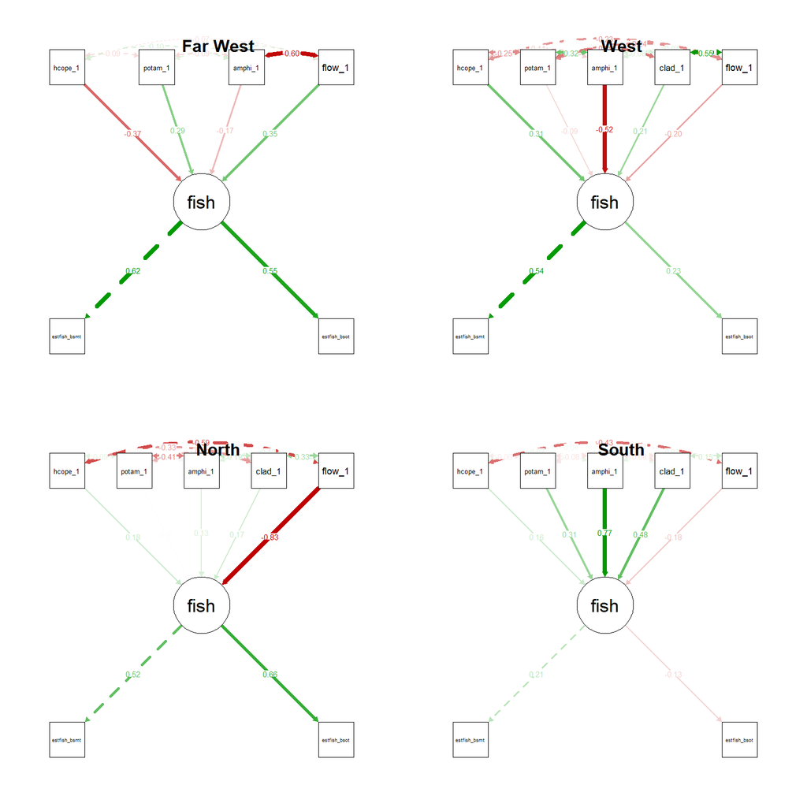

```r
#par(mfrow=c(1,1))
par(mfrow=c(2,2))
semPaths(modfitFW, "std", edge.label.cex = 1, node.width=2, nCharNodes = 0, residuals = F, intercepts = F); title("Far West", line = 1)
semPaths(modfitW, "std", edge.label.cex = 1, node.width=2, nCharNodes = 0, residuals = F, intercepts = F); title("West", line = 1)
semPaths(modfitN, "std", edge.label.cex = 1, node.width=2, nCharNodes = 0, residuals = F, intercepts = F); title("North", line = 1)
semPaths(modfitS, "std", edge.label.cex = 1, node.width=2, nCharNodes = 0, residuals = F, intercepts = F); title("South", line = 1)
```

### Integrated model

???

### Nice plots

These need to be updated.

#### Without covariances

*Far West*

*West*

*North*

*South*